# Project: Investigate a Dataset (Tmdb movie data)

- Introduction
- Data Wrangling
- Exploratory Data Analysis
- Conclusions

## Introduction

**Dataset chosen**: Tmdb movie data

**Description of the dataset**: This data set contains information about 10,000 movies collected from The Movie Database (TMDb), including user ratings and revenue.

**Exploratory questions**:

i)Which movie has the highest budget?

ii)Which movie raked in the highest revenues?

iii)How have the revenue collections fared compared to the budget?

iv)What is the average runtime of the movies?

v)Is the popularity of a movie related to its runtime?

vi)Which year has the maximum number of movies released? Plot a histogram

The above questions are just a small subset of exploratory questions that i plan to investigate using this dataset. There are a lot more questions that could be investigated using the above dataset. I plan to investigate more questions in due course of time.

**Assumptions**:

The budget and revenue are assumed to be in US dollars.

```python
# Use this cell to set up import statements for all of the packages that you
#   plan to use.

# Remember to include a 'magic word' so that your visualizations are plotted
#inline with the notebook. See this page for more:
#http://ipython.readthedocs.io/en/stable/interactive/magics.html
import numpy as np
import pandas as pd
import matplotlib.pyplot as plt
import seaborn as sns
%pylab inline
```

## Data Wrangling

For my exploratory questions, the only data wrangling that needs to be done is to remove columns from the dataframe, which are of not being used in the analysis.

### General Properties

```python
# Load your data and print out a few lines. Perform operations to inspect data
#types and look for instances of missing or possibly errant data.

#First step is to load the csv into a dataframe
filename = "./tmdb-movies.csv"
tmdb_df = pd.read_csv(filename)
```

```python
#Print the top 10 rows of the loaded dataframe
print("Printing the top 10 rows of the loaded dataframe...")
tmdb_df.head(10)
```

```
Printing the top 10 rows of the loaded dataframe...
```

|  | id | imdb_id | popularity | budget | revenue | original_title | cast | homepage | director | tagline | ... | overview | runtime | genres | production_companies | release_date | vote_count | vote_average | release_year | budget_adj | revenue_adj |
| --- | --- | --- | --- | --- | --- | --- | --- | --- | --- | --- | --- | --- | --- | --- | --- | --- | --- | --- | --- | --- | --- |
| 0 | 135397 | tt0369610 | 32.985763 | 150000000 | 1513528810 | Jurassic World | Chris Pratt\|Bryce Dallas Howard\|Irrfan Khan\|Vi... | http://www.jurassicworld.com/ | Colin Trevorrow | The park is open. | ... | Twenty-two years after the events of Jurassic ... | 124 | Action\|Adventure\|Science Fiction\|Thriller | Universal Studios\|Amblin Entertainment\|Legenda... | 6/9/15 | 5562 | 6.5 | 2015 | 1.379999e+08 | 1.392446e+09 |
| 1 | 76341 | tt1392190 | 28.419936 | 150000000 | 378436354 | Mad Max: Fury Road | Tom Hardy\|Charlize Theron\|Hugh Keays-Byrne\|Nic... | http://www.madmaxmovie.com/ | George Miller | What a Lovely Day. | ... | An apocalyptic story set in the furthest reach... | 120 | Action\|Adventure\|Science Fiction\|Thriller | Village Roadshow Pictures\|Kennedy Miller Produ... | 5/13/15 | 6185 | 7.1 | 2015 | 1.379999e+08 | 3.481613e+08 |
| 2 | 262500 | tt2908446 | 13.112507 | 110000000 | 295238201 | Insurgent | Shailene Woodley\|Theo James\|Kate Winslet\|Ansel... | http://www.thedivergentseries.movie/#insurgent | Robert Schwentke | One Choice Can Destroy You | ... | Beatrice Prior must confront her inner demons ... | 119 | Adventure\|Science Fiction\|Thriller | Summit Entertainment\|Mandeville Films\|Red Wago... | 3/18/15 | 2480 | 6.3 | 2015 | 1.012000e+08 | 2.716190e+08 |
| 3 | 140607 | tt2488496 | 11.173104 | 200000000 | 2068178225 | Star Wars: The Force Awakens | Harrison Ford\|Mark Hamill\|Carrie Fisher\|Adam D... | http://www.starwars.com/films/star-wars-episod... | J.J. Abrams | Every generation has a story. | ... | Thirty years after defeating the Galactic Empi... | 136 | Action\|Adventure\|Science Fiction\|Fantasy | Lucasfilm\|Truenorth Productions\|Bad Robot | 12/15/15 | 5292 | 7.5 | 2015 | 1.839999e+08 | 1.902723e+09 |
| 4 | 168259 | tt2820852 | 9.335014 | 190000000 | 1506249360 | Furious 7 | Vin Diesel\|Paul Walker\|Jason Statham\|Michelle ... | http://www.furious7.com/ | James Wan | Vengeance Hits Home | ... | Deckard Shaw seeks revenge against Dominic Tor... | 137 | Action\|Crime\|Thriller | Universal Pictures\|Original Film\|Media Rights ... | 4/1/15 | 2947 | 7.3 | 2015 | 1.747999e+08 | 1.385749e+09 |
| 5 | 281957 | tt1663202 | 9.110700 | 135000000 | 532950503 | The Revenant | Leonardo DiCaprio\|Tom Hardy\|Will Poulter\|Domhn... | http://www.foxmovies.com/movies/the-revenant | Alejandro González Iñárritu | (n. One who has returned, as if from the dead.) | ... | In the 1820s, a frontiersman, Hugh Glass, sets... | 156 | Western\|Drama\|Adventure\|Thriller | Regency Enterprises\|Appian Way\|CatchPlay\|Anony... | 12/25/15 | 3929 | 7.2 | 2015 | 1.241999e+08 | 4.903142e+08 |
| 6 | 87101 | tt1340138 | 8.654359 | 155000000 | 440603537 | Terminator Genisys | Arnold Schwarzenegger\|Jason Clarke\|Emilia Clar... | http://www.terminatormovie.com/ | Alan Taylor | Reset the future | ... | The year is 2029. John Connor, leader of the r... | 125 | Science Fiction\|Action\|Thriller\|Adventure | Paramount Pictures\|Skydance Productions | 6/23/15 | 2598 | 5.8 | 2015 | 1.425999e+08 | 4.053551e+08 |
| 7 | 286217 | tt3659388 | 7.667400 | 108000000 | 595380321 | The Martian | Matt Damon\|Jessica Chastain\|Kristen Wiig\|Jeff ... | http://www.foxmovies.com/movies/the-martian | Ridley Scott | Bring Him Home | ... | During a manned mission to Mars, Astronaut Mar... | 141 | Drama\|Adventure\|Science Fiction | Twentieth Century Fox Film Corporation\|Scott F... | 9/30/15 | 4572 | 7.6 | 2015 | 9.935996e+07 | 5.477497e+08 |
| 8 | 211672 | tt2293640 | 7.404165 | 74000000 | 1156730962 | Minions | Sandra Bullock\|Jon Hamm\|Michael Keaton\|Allison... | http://www.minionsmovie.com/ | Kyle Balda\|Pierre Coffin | Before Gru, they had a history of bad bosses | ... | Minions Stuart, Kevin and Bob are recruited by... | 91 | Family\|Animation\|Adventure\|Comedy | Universal Pictures\|Illumination Entertainment | 6/17/15 | 2893 | 6.5 | 2015 | 6.807997e+07 | 1.064192e+09 |
| 9 | 150540 | tt2096673 | 6.326804 | 175000000 | 853708609 | Inside Out | Amy Poehler\|Phyllis Smith\|Richard Kind\|Bill Ha... | http://movies.disney.com/inside-out | Pete Docter | Meet the little voices inside your head. | ... | Growing up can be a bumpy road, and it's no ex... | 94 | Comedy\|Animation\|Family | Walt Disney Pictures\|Pixar Animation Studios\|W... | 6/9/15 | 3935 | 8.0 | 2015 | 1.609999e+08 | 7.854116e+08 |

10 rows × 21 columns

```python
#Print the bottom 10 rows of the loaded dataframe
print("Printing the bottom 10 rows of the loaded dataframe...")
tmdb_df.tail(10)
```

```
Printing the bottom 10 rows of the loaded dataframe...
```

|  | id | imdb_id | popularity | budget | revenue | original_title | cast | homepage | director | tagline | ... | overview | runtime | genres | production_companies | release_date | vote_count | vote_average | release_year | budget_adj | revenue_adj |
| --- | --- | --- | --- | --- | --- | --- | --- | --- | --- | --- | --- | --- | --- | --- | --- | --- | --- | --- | --- | --- | --- |
| 10856 | 20277 | tt0061135 | 0.140934 | 0 | 0 | The Ugly Dachshund | Dean Jones\|Suzanne Pleshette\|Charles Ruggles\|K... | NaN | Norman Tokar | A HAPPY HONEYMOON GOES TO THE DOGS!...When a G... | ... | The Garrisons (Dean Jones and Suzanne Pleshett... | 93 | Comedy\|Drama\|Family | Walt Disney Pictures | 2/16/66 | 14 | 5.7 | 1966 | 0.000000 | 0.0 |
| 10857 | 5921 | tt0060748 | 0.131378 | 0 | 0 | Nevada Smith | Steve McQueen\|Karl Malden\|Brian Keith\|Arthur K... | NaN | Henry Hathaway | Some called him savage- and some called him sa... | ... | Nevada Smith is the young son of an Indian mot... | 128 | Action\|Western | Paramount Pictures\|Solar Productions\|Embassy P... | 6/10/66 | 10 | 5.9 | 1966 | 0.000000 | 0.0 |
| 10858 | 31918 | tt0060921 | 0.317824 | 0 | 0 | The Russians Are Coming, The Russians Are Coming | Carl Reiner\|Eva Marie Saint\|Alan Arkin\|Brian K... | NaN | Norman Jewison | IT'S A PLOT! ...to make the world die laughing!! | ... | Without hostile intent, a Soviet sub runs agro... | 126 | Comedy\|War | The Mirisch Corporation | 5/25/66 | 11 | 5.5 | 1966 | 0.000000 | 0.0 |
| 10859 | 20620 | tt0060955 | 0.089072 | 0 | 0 | Seconds | Rock Hudson\|Salome Jens\|John Randolph\|Will Gee... | NaN | John Frankenheimer | NaN | ... | A secret organisation offers wealthy people a ... | 100 | Mystery\|Science Fiction\|Thriller\|Drama | Gibraltar Productions\|Joel Productions\|John Fr... | 10/5/66 | 22 | 6.6 | 1966 | 0.000000 | 0.0 |
| 10860 | 5060 | tt0060214 | 0.087034 | 0 | 0 | Carry On Screaming! | Kenneth Williams\|Jim Dale\|Harry H. Corbett\|Joa... | NaN | Gerald Thomas | Carry On Screaming with the Hilarious CARRY ON... | ... | The sinister Dr Watt has an evil scheme going.... | 87 | Comedy | Peter Rogers Productions\|Anglo-Amalgamated Fil... | 5/20/66 | 13 | 7.0 | 1966 | 0.000000 | 0.0 |
| 10861 | 21 | tt0060371 | 0.080598 | 0 | 0 | The Endless Summer | Michael Hynson\|Robert August\|Lord 'Tally Ho' B... | NaN | Bruce Brown | NaN | ... | The Endless Summer, by Bruce Brown, is one of ... | 95 | Documentary | Bruce Brown Films | 6/15/66 | 11 | 7.4 | 1966 | 0.000000 | 0.0 |
| 10862 | 20379 | tt0060472 | 0.065543 | 0 | 0 | Grand Prix | James Garner\|Eva Marie Saint\|Yves Montand\|Tosh... | NaN | John Frankenheimer | Cinerama sweeps YOU into a drama of speed and ... | ... | Grand Prix driver Pete Aron is fired by his te... | 176 | Action\|Adventure\|Drama | Cherokee Productions\|Joel Productions\|Douglas ... | 12/21/66 | 20 | 5.7 | 1966 | 0.000000 | 0.0 |
| 10863 | 39768 | tt0060161 | 0.065141 | 0 | 0 | Beregis Avtomobilya | Innokentiy Smoktunovskiy\|Oleg Efremov\|Georgi Z... | NaN | Eldar Ryazanov | NaN | ... | An insurance agent who moonlights as a carthie... | 94 | Mystery\|Comedy | Mosfilm | 1/1/66 | 11 | 6.5 | 1966 | 0.000000 | 0.0 |
| 10864 | 21449 | tt0061177 | 0.064317 | 0 | 0 | What's Up, Tiger Lily? | Tatsuya Mihashi\|Akiko Wakabayashi\|Mie Hama\|Joh... | NaN | Woody Allen | WOODY ALLEN STRIKES BACK! | ... | In comic Woody Allen's film debut, he took the... | 80 | Action\|Comedy | Benedict Pictures Corp. | 11/2/66 | 22 | 5.4 | 1966 | 0.000000 | 0.0 |
| 10865 | 22293 | tt0060666 | 0.035919 | 19000 | 0 | Manos: The Hands of Fate | Harold P. Warren\|Tom Neyman\|John Reynolds\|Dian... | NaN | Harold P. Warren | It's Shocking! It's Beyond Your Imagination! | ... | A family gets lost on the road and stumbles up... | 74 | Horror | Norm-Iris | 11/15/66 | 15 | 1.5 | 1966 | 127642.279154 | 0.0 |

10 rows × 21 columns

### Observation from bottom 10 rows:

Printing the bottom 10 rows of the dataframe reveals that there are entries in the budget and revenue columns with values of 0. For any meaningful analysis related to budget and revenues, we need to trim the rows where the budget and revenue columns have 0 values.

```python
#Inspect the datatype of all the columns
tmdb_df.dtypes
```

```
id                        int64
imdb_id                  object
popularity              float64
budget                    int64
revenue                   int64
original_title           object
cast                     object
homepage                 object
director                 object
tagline                  object
keywords                 object
overview                 object
runtime                   int64
genres                   object
production_companies     object
release_date             object
vote_count                int64
vote_average            float64
release_year              int64
budget_adj              float64
revenue_adj             float64
dtype: object
```

### Columns of interest in the dataframe:

```python
#Drop all columns other than the columns of interest
cols_to_drop = ['id','homepage','tagline','keywords','overview','genres','budget_adj','revenue_adj']
tmdb_df.drop(cols_to_drop,axis=1,inplace=True)
```

```python
#The dataframe with dropped columsn looks like below
tmdb_df
```

|  | imdb_id | popularity | budget | revenue | original_title | cast | director | runtime | production_companies | release_date | vote_count | vote_average | release_year |
| --- | --- | --- | --- | --- | --- | --- | --- | --- | --- | --- | --- | --- | --- |
| 0 | tt0369610 | 32.985763 | 150000000 | 1513528810 | Jurassic World | Chris Pratt\|Bryce Dallas Howard\|Irrfan Khan\|Vi... | Colin Trevorrow | 124 | Universal Studios\|Amblin Entertainment\|Legenda... | 6/9/15 | 5562 | 6.5 | 2015 |
| 1 | tt1392190 | 28.419936 | 150000000 | 378436354 | Mad Max: Fury Road | Tom Hardy\|Charlize Theron\|Hugh Keays-Byrne\|Nic... | George Miller | 120 | Village Roadshow Pictures\|Kennedy Miller Produ... | 5/13/15 | 6185 | 7.1 | 2015 |
| 2 | tt2908446 | 13.112507 | 110000000 | 295238201 | Insurgent | Shailene Woodley\|Theo James\|Kate Winslet\|Ansel... | Robert Schwentke | 119 | Summit Entertainment\|Mandeville Films\|Red Wago... | 3/18/15 | 2480 | 6.3 | 2015 |
| 3 | tt2488496 | 11.173104 | 200000000 | 2068178225 | Star Wars: The Force Awakens | Harrison Ford\|Mark Hamill\|Carrie Fisher\|Adam D... | J.J. Abrams | 136 | Lucasfilm\|Truenorth Productions\|Bad Robot | 12/15/15 | 5292 | 7.5 | 2015 |
| 4 | tt2820852 | 9.335014 | 190000000 | 1506249360 | Furious 7 | Vin Diesel\|Paul Walker\|Jason Statham\|Michelle ... | James Wan | 137 | Universal Pictures\|Original Film\|Media Rights ... | 4/1/15 | 2947 | 7.3 | 2015 |
| 5 | tt1663202 | 9.110700 | 135000000 | 532950503 | The Revenant | Leonardo DiCaprio\|Tom Hardy\|Will Poulter\|Domhn... | Alejandro González Iñárritu | 156 | Regency Enterprises\|Appian Way\|CatchPlay\|Anony... | 12/25/15 | 3929 | 7.2 | 2015 |
| 6 | tt1340138 | 8.654359 | 155000000 | 440603537 | Terminator Genisys | Arnold Schwarzenegger\|Jason Clarke\|Emilia Clar... | Alan Taylor | 125 | Paramount Pictures\|Skydance Productions | 6/23/15 | 2598 | 5.8 | 2015 |
| 7 | tt3659388 | 7.667400 | 108000000 | 595380321 | The Martian | Matt Damon\|Jessica Chastain\|Kristen Wiig\|Jeff ... | Ridley Scott | 141 | Twentieth Century Fox Film Corporation\|Scott F... | 9/30/15 | 4572 | 7.6 | 2015 |
| 8 | tt2293640 | 7.404165 | 74000000 | 1156730962 | Minions | Sandra Bullock\|Jon Hamm\|Michael Keaton\|Allison... | Kyle Balda\|Pierre Coffin | 91 | Universal Pictures\|Illumination Entertainment | 6/17/15 | 2893 | 6.5 | 2015 |
| 9 | tt2096673 | 6.326804 | 175000000 | 853708609 | Inside Out | Amy Poehler\|Phyllis Smith\|Richard Kind\|Bill Ha... | Pete Docter | 94 | Walt Disney Pictures\|Pixar Animation Studios\|W... | 6/9/15 | 3935 | 8.0 | 2015 |
| 10 | tt2379713 | 6.200282 | 245000000 | 880674609 | Spectre | Daniel Craig\|Christoph Waltz\|Léa Seydoux\|Ralp... | Sam Mendes | 148 | Columbia Pictures\|Danjaq\|B24 | 10/26/15 | 3254 | 6.2 | 2015 |
| 11 | tt1617661 | 6.189369 | 176000003 | 183987723 | Jupiter Ascending | Mila Kunis\|Channing Tatum\|Sean Bean\|Eddie Redm... | Lana Wachowski\|Lilly Wachowski | 124 | Village Roadshow Pictures\|Dune Entertainment\|A... | 2/4/15 | 1937 | 5.2 | 2015 |
| 12 | tt0470752 | 6.118847 | 15000000 | 36869414 | Ex Machina | Domhnall Gleeson\|Alicia Vikander\|Oscar Isaac\|S... | Alex Garland | 108 | DNA Films\|Universal Pictures International (UP... | 1/21/15 | 2854 | 7.6 | 2015 |
| 13 | tt2120120 | 5.984995 | 88000000 | 243637091 | Pixels | Adam Sandler\|Michelle Monaghan\|Peter Dinklage\|... | Chris Columbus | 105 | Columbia Pictures\|Happy Madison Productions | 7/16/15 | 1575 | 5.8 | 2015 |
| 14 | tt2395427 | 5.944927 | 280000000 | 1405035767 | Avengers: Age of Ultron | Robert Downey Jr.\|Chris Hemsworth\|Mark Ruffalo... | Joss Whedon | 141 | Marvel Studios\|Prime Focus\|Revolution Sun Studios | 4/22/15 | 4304 | 7.4 | 2015 |
| 15 | tt3460252 | 5.898400 | 44000000 | 155760117 | The Hateful Eight | Samuel L. Jackson\|Kurt Russell\|Jennifer Jason ... | Quentin Tarantino | 167 | Double Feature Films\|The Weinstein Company\|Fil... | 12/25/15 | 2389 | 7.4 | 2015 |
| 16 | tt2446042 | 5.749758 | 48000000 | 325771424 | Taken 3 | Liam Neeson\|Forest Whitaker\|Maggie Grace\|Famke... | Olivier Megaton | 109 | Twentieth Century Fox Film Corporation\|M6 Film... | 1/1/15 | 1578 | 6.1 | 2015 |
| 17 | tt0478970 | 5.573184 | 130000000 | 518602163 | Ant-Man | Paul Rudd\|Michael Douglas\|Evangeline Lilly\|Cor... | Peyton Reed | 115 | Marvel Studios | 7/14/15 | 3779 | 7.0 | 2015 |
| 18 | tt1661199 | 5.556818 | 95000000 | 542351353 | Cinderella | Lily James\|Cate Blanchett\|Richard Madden\|Helen... | Kenneth Branagh | 112 | Walt Disney Pictures\|Genre Films\|Beagle Pug Fi... | 3/12/15 | 1495 | 6.8 | 2015 |
| 19 | tt1951266 | 5.476958 | 160000000 | 650523427 | The Hunger Games: Mockingjay - Part 2 | Jennifer Lawrence\|Josh Hutcherson\|Liam Hemswor... | Francis Lawrence | 136 | Studio Babelsberg\|StudioCanal\|Lionsgate\|Walt D... | 11/18/15 | 2380 | 6.5 | 2015 |
| 20 | tt1964418 | 5.462138 | 190000000 | 209035668 | Tomorrowland | Britt Robertson\|George Clooney\|Raffey Cassidy\|... | Brad Bird | 130 | Walt Disney Pictures\|Babieka\|A113 | 5/19/15 | 1899 | 6.2 | 2015 |
| 21 | tt1798684 | 5.337064 | 30000000 | 91709827 | Southpaw | Jake Gyllenhaal\|Rachel McAdams\|Forest Whitaker... | Antoine Fuqua | 123 | Escape Artists\|Riche-Ludwig Productions | 6/15/15 | 1386 | 7.3 | 2015 |
| 22 | tt2126355 | 4.907832 | 110000000 | 470490832 | San Andreas | Dwayne Johnson\|Alexandra Daddario\|Carla Gugino... | Brad Peyton | 114 | New Line Cinema\|Village Roadshow Pictures\|Warn... | 5/27/15 | 2060 | 6.1 | 2015 |
| 23 | tt2322441 | 4.710402 | 40000000 | 569651467 | Fifty Shades of Grey | Dakota Johnson\|Jamie Dornan\|Jennifer Ehle\|Eloi... | Sam Taylor-Johnson | 125 | Focus Features\|Trigger Street Productions\|Mich... | 2/11/15 | 1865 | 5.3 | 2015 |
| 24 | tt1596363 | 4.648046 | 28000000 | 133346506 | The Big Short | Christian Bale\|Steve Carell\|Ryan Gosling\|Brad ... | Adam McKay | 130 | Paramount Pictures\|Plan B Entertainment\|Regenc... | 12/11/15 | 1545 | 7.3 | 2015 |
| 25 | tt2381249 | 4.566713 | 150000000 | 682330139 | Mission: Impossible - Rogue Nation | Tom Cruise\|Jeremy Renner\|Simon Pegg\|Rebecca Fe... | Christopher McQuarrie | 131 | Paramount Pictures\|Skydance Productions\|China ... | 7/23/15 | 2349 | 7.1 | 2015 |
| 26 | tt2637276 | 4.564549 | 68000000 | 215863606 | Ted 2 | Mark Wahlberg\|Seth MacFarlane\|Amanda Seyfried\|... | Seth MacFarlane | 115 | Universal Pictures\|Media Rights Capital\|Fuzzy ... | 6/25/15 | 1666 | 6.3 | 2015 |
| 27 | tt2802144 | 4.503789 | 81000000 | 403802136 | Kingsman: The Secret Service | Taron Egerton\|Colin Firth\|Samuel L. Jackson\|Mi... | Matthew Vaughn | 130 | Twentieth Century Fox Film Corporation\|Marv Fi... | 1/24/15 | 3833 | 7.6 | 2015 |
| 28 | tt1895587 | 4.062293 | 20000000 | 88346473 | Spotlight | Mark Ruffalo\|Michael Keaton\|Rachel McAdams\|Lie... | Tom McCarthy | 128 | Participant Media\|Open Road Films\|Anonymous Co... | 11/6/15 | 1559 | 7.8 | 2015 |
| 29 | tt4046784 | 3.968891 | 61000000 | 311256926 | Maze Runner: The Scorch Trials | Dylan O'Brien\|Kaya Scodelario\|Thomas Brodie-Sa... | Wes Ball | 132 | Gotham Group\|Temple Hill Entertainment\|TSG Ent... | 9/9/15 | 1849 | 6.4 | 2015 |
| ... | ... | ... | ... | ... | ... | ... | ... | ... | ... | ... | ... | ... | ... |
| 10836 | tt0061170 | 0.239435 | 0 | 0 | Walk Don't Run | Cary Grant\|Samantha Eggar\|Jim Hutton\|John Stan... | Charles Walters | 114 | Columbia Pictures Corporation | 1/1/66 | 11 | 5.8 | 1966 |
| 10837 | tt0060177 | 0.291704 | 0 | 0 | The Blue Max | George Peppard\|James Mason\|Ursula Andress\|Jere... | John Guillermin | 156 | Twentieth Century Fox Film Corporation | 6/21/66 | 12 | 5.5 | 1966 |
| 10838 | tt0060862 | 0.151845 | 0 | 0 | The Professionals | Burt Lancaster\|Lee Marvin\|Robert Ryan\|Woody St... | Richard Brooks | 117 | Columbia Pictures | 11/1/66 | 21 | 6.0 | 1966 |
| 10839 | tt0060550 | 0.276133 | 0 | 0 | It's the Great Pumpkin, Charlie Brown | Christopher Shea\|Sally Dryer\|Kathy Steinberg\|A... | Bill Melendez | 25 | Warner Bros. Home Video | 10/27/66 | 49 | 7.2 | 1966 |
| 10840 | tt0060437 | 0.102530 | 0 | 0 | Funeral in Berlin | Michael Caine\|Paul Hubschmid\|Oskar Homolka\|Eva... | Guy Hamilton | 102 | Lowndes Productions Limited | 12/22/66 | 13 | 5.7 | 1966 |
| 10841 | tt0062262 | 0.264925 | 75000 | 0 | The Shooting | Will Hutchins\|Millie Perkins\|Jack Nicholson\|Wa... | Monte Hellman | 82 | Proteus Films | 10/23/66 | 12 | 5.5 | 1966 |
| 10842 | tt0061199 | 0.253437 | 0 | 0 | Winnie the Pooh and the Honey Tree | Sterling Holloway\|Junius Matthews\|Sebastian Ca... | Wolfgang Reitherman | 25 | NaN | 1/1/66 | 12 | 7.9 | 1966 |
| 10843 | tt0060588 | 0.252399 | 0 | 0 | Khartoum | Charlton Heston\|Laurence Olivier\|Richard Johns... | Basil Dearden\|Eliot Elisofon | 134 | Julian Blaustein Productions Ltd. | 6/9/66 | 12 | 5.8 | 1966 |
| 10844 | tt0059557 | 0.236098 | 0 | 0 | Our Man Flint | James Coburn\|Lee J. Cobb\|Gila Golan\|Edward Mul... | Daniel Mann | 108 | 20th Century Fox | 1/16/66 | 13 | 5.6 | 1966 |
| 10845 | tt0059014 | 0.230873 | 0 | 0 | Carry On Cowboy | Sid James\|Jim Dale\|Angela Douglas\|Kenneth Will... | Gerald Thomas | 93 | Peter Rogers Productions | 3/1/66 | 15 | 5.9 | 1966 |
| 10846 | tt0059127 | 0.212716 | 0 | 0 | Dracula: Prince of Darkness | Christopher Lee\|Barbara Shelley\|Andrew Keir\|Fr... | Terence Fisher | 90 | Seven Arts Productions\|Hammer Film Productions | 1/9/66 | 16 | 5.7 | 1966 |
| 10847 | tt0060548 | 0.034555 | 0 | 0 | Island of Terror | Peter Cushing\|Edward Judd\|Carole Gray\|Eddie By... | Terence Fisher | 89 | Planet Film Productions\|Protelco | 6/20/66 | 13 | 5.3 | 1966 |
| 10848 | tt0060397 | 0.207257 | 5115000 | 12000000 | Fantastic Voyage | Stephen Boyd\|Raquel Welch\|Edmond O'Brien\|Donal... | Richard Fleischer | 100 | Twentieth Century Fox Film Corporation | 8/24/66 | 42 | 6.7 | 1966 |
| 10849 | tt0060445 | 0.206537 | 0 | 0 | Gambit | Michael Caine\|Shirley MacLaine\|Herbert Lom\|Joh... | Ronald Neame | 109 | Universal Pictures | 12/16/66 | 14 | 6.1 | 1966 |
| 10850 | tt0060490 | 0.202473 | 0 | 0 | Harper | Paul Newman\|Lauren Bacall\|Julie Harris\|Arthur ... | Jack Smight | 121 | Warner Bros. | 2/23/66 | 14 | 6.0 | 1966 |
| 10851 | tt0060182 | 0.342791 | 0 | 0 | Born Free | Virginia McKenna\|Bill Travers\|Geoffrey Keen\|Pe... | James Hill | 95 | High Road | 6/22/66 | 15 | 6.6 | 1966 |
| 10852 | tt0060165 | 0.227220 | 0 | 0 | A Big Hand for the Little Lady | Henry Fonda\|Joanne Woodward\|Jason Robards\|Paul... | Fielder Cook | 95 | Eden Productions Inc. | 5/31/66 | 11 | 6.0 | 1966 |
| 10853 | tt0060086 | 0.163592 | 0 | 0 | Alfie | Michael Caine\|Shelley Winters\|Millicent Martin... | Lewis Gilbert | 114 | NaN | 3/29/66 | 26 | 6.2 | 1966 |
| 10854 | tt0060232 | 0.146402 | 0 | 0 | The Chase | Marlon Brando\|Jane Fonda\|Robert Redford\|E.G. M... | Arthur Penn | 135 | Horizon Pictures\|Columbia Pictures Corporation | 2/17/66 | 17 | 6.0 | 1966 |
| 10855 | tt0059221 | 0.141026 | 700000 | 0 | The Ghost & Mr. Chicken | Don Knotts\|Joan Staley\|Liam Redmond\|Dick Sarge... | Alan Rafkin | 90 | Universal Pictures | 1/20/66 | 14 | 6.1 | 1966 |
| 10856 | tt0061135 | 0.140934 | 0 | 0 | The Ugly Dachshund | Dean Jones\|Suzanne Pleshette\|Charles Ruggles\|K... | Norman Tokar | 93 | Walt Disney Pictures | 2/16/66 | 14 | 5.7 | 1966 |
| 10857 | tt0060748 | 0.131378 | 0 | 0 | Nevada Smith | Steve McQueen\|Karl Malden\|Brian Keith\|Arthur K... | Henry Hathaway | 128 | Paramount Pictures\|Solar Productions\|Embassy P... | 6/10/66 | 10 | 5.9 | 1966 |
| 10858 | tt0060921 | 0.317824 | 0 | 0 | The Russians Are Coming, The Russians Are Coming | Carl Reiner\|Eva Marie Saint\|Alan Arkin\|Brian K... | Norman Jewison | 126 | The Mirisch Corporation | 5/25/66 | 11 | 5.5 | 1966 |
| 10859 | tt0060955 | 0.089072 | 0 | 0 | Seconds | Rock Hudson\|Salome Jens\|John Randolph\|Will Gee... | John Frankenheimer | 100 | Gibraltar Productions\|Joel Productions\|John Fr... | 10/5/66 | 22 | 6.6 | 1966 |
| 10860 | tt0060214 | 0.087034 | 0 | 0 | Carry On Screaming! | Kenneth Williams\|Jim Dale\|Harry H. Corbett\|Joa... | Gerald Thomas | 87 | Peter Rogers Productions\|Anglo-Amalgamated Fil... | 5/20/66 | 13 | 7.0 | 1966 |
| 10861 | tt0060371 | 0.080598 | 0 | 0 | The Endless Summer | Michael Hynson\|Robert August\|Lord 'Tally Ho' B... | Bruce Brown | 95 | Bruce Brown Films | 6/15/66 | 11 | 7.4 | 1966 |
| 10862 | tt0060472 | 0.065543 | 0 | 0 | Grand Prix | James Garner\|Eva Marie Saint\|Yves Montand\|Tosh... | John Frankenheimer | 176 | Cherokee Productions\|Joel Productions\|Douglas ... | 12/21/66 | 20 | 5.7 | 1966 |
| 10863 | tt0060161 | 0.065141 | 0 | 0 | Beregis Avtomobilya | Innokentiy Smoktunovskiy\|Oleg Efremov\|Georgi Z... | Eldar Ryazanov | 94 | Mosfilm | 1/1/66 | 11 | 6.5 | 1966 |
| 10864 | tt0061177 | 0.064317 | 0 | 0 | What's Up, Tiger Lily? | Tatsuya Mihashi\|Akiko Wakabayashi\|Mie Hama\|Joh... | Woody Allen | 80 | Benedict Pictures Corp. | 11/2/66 | 22 | 5.4 | 1966 |
| 10865 | tt0060666 | 0.035919 | 19000 | 0 | Manos: The Hands of Fate | Harold P. Warren\|Tom Neyman\|John Reynolds\|Dian... | Harold P. Warren | 74 | Norm-Iris | 11/15/66 | 15 | 1.5 | 1966 |

10866 rows × 13 columns

### Data Cleaning

The data cleaning process consists of the following steps:

i)Drop duplicate rows, if any

#### Reason for filtering the data in the budget and revenue column

In this new dataframe with reduced number of columns, we now need to filter rows which contain 0 in either the budget or the revenue columns. We are doing this as one of the exploratory questions deals about determining if higher budget movies translate into higher revenues.

```python
#Get the number of rows in the dataframe before any cleanup is done.
len_before_cleanup = len(tmdb_df.index)
print("Total number of records before data cleanup is:{}".format(len_before_cleanup))
```

```
Total number of records before data cleanup is:10866
```

```python
#Start inspection of the data.
#First step is to make sure that there are no duplicates in the csv file.
tmdb_df.drop_duplicates(keep = 'first', inplace = True)
len_after_cleanup = len(tmdb_df.index)
print("Total number of records after cleanup is:{}".format(len_after_cleanup))
```

```
Total number of records after cleanup is:10865
```

#### **Observation after data cleanup**:

It seems like one duplicate row has been cleaned after the data cleanup operation.

```python
#Filter rows where either the budget,revenue or the runtime  is not greater than 0
#This step ensures that the dataframe contains only rows with valid values for budget, revenue and runtime.
tmdb_df = tmdb_df[(tmdb_df.budget > 0) & (tmdb_df.revenue > 0) & (tmdb_df.runtime > 0)]
```

```python
#Inspect the number of row remaining after the data cleanup operation.
print("Total number of records in the dataframe after the final data cleanup operation is:{}".format(len(tmdb_df)))
tmdb_df
```

```
Total number of records in the dataframe after the final data cleanup operation is:3854
```

|  | imdb_id | popularity | budget | revenue | original_title | cast | director | runtime | production_companies | release_date | vote_count | vote_average | release_year |
| --- | --- | --- | --- | --- | --- | --- | --- | --- | --- | --- | --- | --- | --- |
| 0 | tt0369610 | 32.985763 | 150000000 | 1513528810 | Jurassic World | Chris Pratt\|Bryce Dallas Howard\|Irrfan Khan\|Vi... | Colin Trevorrow | 124 | Universal Studios\|Amblin Entertainment\|Legenda... | 6/9/15 | 5562 | 6.5 | 2015 |
| 1 | tt1392190 | 28.419936 | 150000000 | 378436354 | Mad Max: Fury Road | Tom Hardy\|Charlize Theron\|Hugh Keays-Byrne\|Nic... | George Miller | 120 | Village Roadshow Pictures\|Kennedy Miller Produ... | 5/13/15 | 6185 | 7.1 | 2015 |
| 2 | tt2908446 | 13.112507 | 110000000 | 295238201 | Insurgent | Shailene Woodley\|Theo James\|Kate Winslet\|Ansel... | Robert Schwentke | 119 | Summit Entertainment\|Mandeville Films\|Red Wago... | 3/18/15 | 2480 | 6.3 | 2015 |
| 3 | tt2488496 | 11.173104 | 200000000 | 2068178225 | Star Wars: The Force Awakens | Harrison Ford\|Mark Hamill\|Carrie Fisher\|Adam D... | J.J. Abrams | 136 | Lucasfilm\|Truenorth Productions\|Bad Robot | 12/15/15 | 5292 | 7.5 | 2015 |
| 4 | tt2820852 | 9.335014 | 190000000 | 1506249360 | Furious 7 | Vin Diesel\|Paul Walker\|Jason Statham\|Michelle ... | James Wan | 137 | Universal Pictures\|Original Film\|Media Rights ... | 4/1/15 | 2947 | 7.3 | 2015 |
| 5 | tt1663202 | 9.110700 | 135000000 | 532950503 | The Revenant | Leonardo DiCaprio\|Tom Hardy\|Will Poulter\|Domhn... | Alejandro González Iñárritu | 156 | Regency Enterprises\|Appian Way\|CatchPlay\|Anony... | 12/25/15 | 3929 | 7.2 | 2015 |
| 6 | tt1340138 | 8.654359 | 155000000 | 440603537 | Terminator Genisys | Arnold Schwarzenegger\|Jason Clarke\|Emilia Clar... | Alan Taylor | 125 | Paramount Pictures\|Skydance Productions | 6/23/15 | 2598 | 5.8 | 2015 |
| 7 | tt3659388 | 7.667400 | 108000000 | 595380321 | The Martian | Matt Damon\|Jessica Chastain\|Kristen Wiig\|Jeff ... | Ridley Scott | 141 | Twentieth Century Fox Film Corporation\|Scott F... | 9/30/15 | 4572 | 7.6 | 2015 |
| 8 | tt2293640 | 7.404165 | 74000000 | 1156730962 | Minions | Sandra Bullock\|Jon Hamm\|Michael Keaton\|Allison... | Kyle Balda\|Pierre Coffin | 91 | Universal Pictures\|Illumination Entertainment | 6/17/15 | 2893 | 6.5 | 2015 |
| 9 | tt2096673 | 6.326804 | 175000000 | 853708609 | Inside Out | Amy Poehler\|Phyllis Smith\|Richard Kind\|Bill Ha... | Pete Docter | 94 | Walt Disney Pictures\|Pixar Animation Studios\|W... | 6/9/15 | 3935 | 8.0 | 2015 |
| 10 | tt2379713 | 6.200282 | 245000000 | 880674609 | Spectre | Daniel Craig\|Christoph Waltz\|Léa Seydoux\|Ralp... | Sam Mendes | 148 | Columbia Pictures\|Danjaq\|B24 | 10/26/15 | 3254 | 6.2 | 2015 |
| 11 | tt1617661 | 6.189369 | 176000003 | 183987723 | Jupiter Ascending | Mila Kunis\|Channing Tatum\|Sean Bean\|Eddie Redm... | Lana Wachowski\|Lilly Wachowski | 124 | Village Roadshow Pictures\|Dune Entertainment\|A... | 2/4/15 | 1937 | 5.2 | 2015 |
| 12 | tt0470752 | 6.118847 | 15000000 | 36869414 | Ex Machina | Domhnall Gleeson\|Alicia Vikander\|Oscar Isaac\|S... | Alex Garland | 108 | DNA Films\|Universal Pictures International (UP... | 1/21/15 | 2854 | 7.6 | 2015 |
| 13 | tt2120120 | 5.984995 | 88000000 | 243637091 | Pixels | Adam Sandler\|Michelle Monaghan\|Peter Dinklage\|... | Chris Columbus | 105 | Columbia Pictures\|Happy Madison Productions | 7/16/15 | 1575 | 5.8 | 2015 |
| 14 | tt2395427 | 5.944927 | 280000000 | 1405035767 | Avengers: Age of Ultron | Robert Downey Jr.\|Chris Hemsworth\|Mark Ruffalo... | Joss Whedon | 141 | Marvel Studios\|Prime Focus\|Revolution Sun Studios | 4/22/15 | 4304 | 7.4 | 2015 |
| 15 | tt3460252 | 5.898400 | 44000000 | 155760117 | The Hateful Eight | Samuel L. Jackson\|Kurt Russell\|Jennifer Jason ... | Quentin Tarantino | 167 | Double Feature Films\|The Weinstein Company\|Fil... | 12/25/15 | 2389 | 7.4 | 2015 |
| 16 | tt2446042 | 5.749758 | 48000000 | 325771424 | Taken 3 | Liam Neeson\|Forest Whitaker\|Maggie Grace\|Famke... | Olivier Megaton | 109 | Twentieth Century Fox Film Corporation\|M6 Film... | 1/1/15 | 1578 | 6.1 | 2015 |
| 17 | tt0478970 | 5.573184 | 130000000 | 518602163 | Ant-Man | Paul Rudd\|Michael Douglas\|Evangeline Lilly\|Cor... | Peyton Reed | 115 | Marvel Studios | 7/14/15 | 3779 | 7.0 | 2015 |
| 18 | tt1661199 | 5.556818 | 95000000 | 542351353 | Cinderella | Lily James\|Cate Blanchett\|Richard Madden\|Helen... | Kenneth Branagh | 112 | Walt Disney Pictures\|Genre Films\|Beagle Pug Fi... | 3/12/15 | 1495 | 6.8 | 2015 |
| 19 | tt1951266 | 5.476958 | 160000000 | 650523427 | The Hunger Games: Mockingjay - Part 2 | Jennifer Lawrence\|Josh Hutcherson\|Liam Hemswor... | Francis Lawrence | 136 | Studio Babelsberg\|StudioCanal\|Lionsgate\|Walt D... | 11/18/15 | 2380 | 6.5 | 2015 |
| 20 | tt1964418 | 5.462138 | 190000000 | 209035668 | Tomorrowland | Britt Robertson\|George Clooney\|Raffey Cassidy\|... | Brad Bird | 130 | Walt Disney Pictures\|Babieka\|A113 | 5/19/15 | 1899 | 6.2 | 2015 |
| 21 | tt1798684 | 5.337064 | 30000000 | 91709827 | Southpaw | Jake Gyllenhaal\|Rachel McAdams\|Forest Whitaker... | Antoine Fuqua | 123 | Escape Artists\|Riche-Ludwig Productions | 6/15/15 | 1386 | 7.3 | 2015 |
| 22 | tt2126355 | 4.907832 | 110000000 | 470490832 | San Andreas | Dwayne Johnson\|Alexandra Daddario\|Carla Gugino... | Brad Peyton | 114 | New Line Cinema\|Village Roadshow Pictures\|Warn... | 5/27/15 | 2060 | 6.1 | 2015 |
| 23 | tt2322441 | 4.710402 | 40000000 | 569651467 | Fifty Shades of Grey | Dakota Johnson\|Jamie Dornan\|Jennifer Ehle\|Eloi... | Sam Taylor-Johnson | 125 | Focus Features\|Trigger Street Productions\|Mich... | 2/11/15 | 1865 | 5.3 | 2015 |
| 24 | tt1596363 | 4.648046 | 28000000 | 133346506 | The Big Short | Christian Bale\|Steve Carell\|Ryan Gosling\|Brad ... | Adam McKay | 130 | Paramount Pictures\|Plan B Entertainment\|Regenc... | 12/11/15 | 1545 | 7.3 | 2015 |
| 25 | tt2381249 | 4.566713 | 150000000 | 682330139 | Mission: Impossible - Rogue Nation | Tom Cruise\|Jeremy Renner\|Simon Pegg\|Rebecca Fe... | Christopher McQuarrie | 131 | Paramount Pictures\|Skydance Productions\|China ... | 7/23/15 | 2349 | 7.1 | 2015 |
| 26 | tt2637276 | 4.564549 | 68000000 | 215863606 | Ted 2 | Mark Wahlberg\|Seth MacFarlane\|Amanda Seyfried\|... | Seth MacFarlane | 115 | Universal Pictures\|Media Rights Capital\|Fuzzy ... | 6/25/15 | 1666 | 6.3 | 2015 |
| 27 | tt2802144 | 4.503789 | 81000000 | 403802136 | Kingsman: The Secret Service | Taron Egerton\|Colin Firth\|Samuel L. Jackson\|Mi... | Matthew Vaughn | 130 | Twentieth Century Fox Film Corporation\|Marv Fi... | 1/24/15 | 3833 | 7.6 | 2015 |
| 28 | tt1895587 | 4.062293 | 20000000 | 88346473 | Spotlight | Mark Ruffalo\|Michael Keaton\|Rachel McAdams\|Lie... | Tom McCarthy | 128 | Participant Media\|Open Road Films\|Anonymous Co... | 11/6/15 | 1559 | 7.8 | 2015 |
| 29 | tt4046784 | 3.968891 | 61000000 | 311256926 | Maze Runner: The Scorch Trials | Dylan O'Brien\|Kaya Scodelario\|Thomas Brodie-Sa... | Wes Ball | 132 | Gotham Group\|Temple Hill Entertainment\|TSG Ent... | 9/9/15 | 1849 | 6.4 | 2015 |
| ... | ... | ... | ... | ... | ... | ... | ... | ... | ... | ... | ... | ... | ... |
| 10690 | tt0059742 | 1.313676 | 8200000 | 163214286 | The Sound of Music | Julie Andrews\|Christopher Plummer\|Eleanor Park... | Robert Wise | 174 | Robert Wise Productions\|Argyle Enterprises | 3/2/65 | 620 | 7.2 | 1965 |
| 10691 | tt0059113 | 1.282053 | 14000000 | 111721910 | Doctor Zhivago | Omar Sharif\|Julie Christie\|Geraldine Chaplin\|R... | David Lean | 197 | Metro-Goldwyn-Mayer (MGM) | 12/22/65 | 126 | 6.9 | 1965 |
| 10692 | tt0059797 | 0.622157 | 5600000 | 29950000 | Those Magnificent Men in Their Flying Machines... | Stuart Whitman\|Sarah Miles\|James Fox\|Alberto S... | Ken Annakin | 138 | Twentieth Century-Fox Productions | 6/3/65 | 19 | 6.6 | 1965 |
| 10716 | tt0059245 | 0.146033 | 20000000 | 12000000 | The Greatest Story Ever Told | Max von Sydow\|Michael Anderson Jr.\|Carroll Bak... | George Stevens | 199 | George Stevens Productions | 2/15/65 | 13 | 5.7 | 1965 |
| 10724 | tt0064757 | 1.778746 | 7000000 | 81974493 | On Her Majesty's Secret Service | George Lazenby\|Diana Rigg\|Telly Savalas\|Gabrie... | Peter R. Hunt | 142 | Eon Productions\|Metro-Goldwyn-Mayer (MGM)\|Danjaq | 12/12/69 | 258 | 6.4 | 1969 |
| 10725 | tt0064115 | 1.357317 | 6000000 | 102308889 | Butch Cassidy and the Sundance Kid | Paul Newman\|Robert Redford\|Katharine Ross\|Stro... | George Roy Hill | 110 | Twentieth Century Fox Film Corporation\|Campani... | 9/23/69 | 379 | 7.0 | 1969 |
| 10727 | tt0064665 | 0.859806 | 3600000 | 44785053 | Midnight Cowboy | Dustin Hoffman\|Jon Voight\|Sylvia Miles\|John Mc... | John Schlesinger | 113 | United Artists\|Florin Productions\|Jerome Hellm... | 5/25/69 | 124 | 7.0 | 1969 |
| 10728 | tt0065214 | 0.615889 | 6244087 | 638641 | The Wild Bunch | Ernest Borgnine\|William Holden\|Robert Ryan\|Edm... | Sam Peckinpah | 145 | Warner Brothers/Seven Arts | 6/17/69 | 121 | 7.2 | 1969 |
| 10755 | tt0077631 | 1.697618 | 6000000 | 181813770 | Grease | John Travolta\|Olivia Newton-John\|Stockard Chan... | Randal Kleiser | 110 | Paramount Pictures\|Robert Stigwood Organizatio... | 7/7/78 | 786 | 7.0 | 1978 |
| 10756 | tt0077766 | 1.562700 | 20000000 | 187884007 | Jaws 2 | Roy Scheider\|Lorraine Gary\|Murray Hamilton\|Jos... | Jeannot Szwarc | 116 | Universal Pictures | 6/16/78 | 179 | 5.5 | 1978 |
| 10757 | tt0077402 | 1.210531 | 650000 | 55000000 | Dawn of the Dead | David Emge\|Ken Foree\|Scott H. Reiniger\|Gaylen ... | George A. Romero | 127 | Laurel Group\|Dawn Associates | 9/2/78 | 306 | 7.2 | 1978 |
| 10758 | tt0078346 | 1.210324 | 55000000 | 300218018 | Superman | Marlon Brando\|Gene Hackman\|Christopher Reeve\|N... | Richard Donner | 143 | Warner Bros.\|Dovemead Films\|Film Export A.G. | 12/14/78 | 518 | 6.7 | 1978 |
| 10759 | tt0077651 | 1.198849 | 300000 | 70000000 | Halloween | Donald Pleasence\|Jamie Lee Curtis\|P.J. Soles\|N... | John Carpenter | 91 | Compass International Pictures\|Falcon Internat... | 10/25/78 | 522 | 7.3 | 1978 |
| 10760 | tt0077975 | 1.157930 | 2700000 | 141000000 | Animal House | John Belushi\|Tim Matheson\|John Vernon\|Verna Bl... | John Landis | 109 | Universal Pictures\|Oregon Film Factory\|Stage I... | 7/27/78 | 230 | 6.7 | 1978 |
| 10762 | tt0077416 | 0.959754 | 15000000 | 50000000 | The Deer Hunter | Robert De Niro\|John Cazale\|John Savage\|Christo... | Michael Cimino | 183 | Universal Pictures\|EMI Films Ltd. | 12/8/78 | 464 | 7.4 | 1978 |
| 10770 | tt0077928 | 0.512719 | 2300000 | 35000000 | Midnight Express | Brad Davis\|Irene Miracle\|Bo Hopkins\|Randy Quai... | Alan Parker | 121 | Columbia Pictures\|Casablanca Filmworks | 10/6/78 | 141 | 7.5 | 1978 |
| 10771 | tt0077869 | 0.496029 | 4000000 | 30471420 | The Lord of the Rings | Christopher Guard\|William Squire\|Michael Schol... | Ralph Bakshi | 132 | Fantasy Films | 11/15/78 | 91 | 6.0 | 1978 |
| 10775 | tt0077413 | 0.468871 | 7920000 | 14560084 | Death on the Nile | Peter Ustinov\|Mia Farrow\|Simon MacCorkindale\|L... | John Guillermin | 140 | EMI Films Ltd.\|Mersham Productions | 10/6/78 | 51 | 6.2 | 1978 |
| 10777 | tt0077531 | 0.439210 | 11 | 11 | F.I.S.T. | Sylvester Stallone\|Rod Steiger\|Peter Boyle\|Mel... | Norman Jewison | 145 | chateau productions | 4/26/78 | 13 | 6.7 | 1978 |
| 10778 | tt0077572 | 0.435312 | 5000000 | 7230000 | Force 10 from Navarone | Harrison Ford\|Robert Shaw\|Barbara Bach\|Edward ... | Guy Hamilton | 118 | Columbia Pictures Corporation | 11/1/78 | 39 | 6.6 | 1978 |
| 10779 | tt0077369 | 0.411826 | 12000000 | 22765081 | Convoy | Kris Kristofferson\|Ali MacGraw\|Ernest Borgnine... | Sam Peckinpah | 110 | EMI Films Ltd. | 6/27/78 | 31 | 6.2 | 1978 |
| 10780 | tt0077745 | 0.409377 | 3500000 | 24046533 | Invasion of the Body Snatchers | Donald Sutherland\|Brooke Adams\|Leonard Nimoy\|V... | Philip Kaufman | 115 | United Artists\|Solofilm | 12/19/78 | 87 | 6.5 | 1978 |
| 10788 | tt0078504 | 0.277769 | 24000000 | 21049053 | The Wiz | Diana Ross\|Michael Jackson\|Nipsey Russell\|Ted ... | Sidney Lumet | 134 | Universal Pictures\|Motown Productions | 10/24/78 | 30 | 6.1 | 1978 |
| 10791 | tt0077394 | 0.236193 | 6800000 | 26518355 | Damien: Omen II | William Holden\|Lee Grant\|Jonathan Scott-Taylor... | Don Taylor\|Mike Hodges | 107 | Twentieth Century Fox Film Corporation\|Mace Ne... | 6/9/78 | 71 | 6.1 | 1978 |
| 10793 | tt0078480 | 0.226002 | 1000000 | 3713768 | Watership Down | John Hurt\|Richard Briers\|Michael Graham Cox\|Jo... | Martin Rosen | 88 | Nepenthe Productions\|Watership Productions | 10/14/78 | 67 | 6.8 | 1978 |
| 10822 | tt0061184 | 0.670274 | 7500000 | 33736689 | Who's Afraid of Virginia Woolf? | Elizabeth Taylor\|Richard Burton\|George Segal\|S... | Mike Nichols | 131 | Chenault Productions | 6/21/66 | 74 | 7.5 | 1966 |
| 10828 | tt0061107 | 0.402730 | 3000000 | 13000000 | Torn Curtain | Paul Newman\|Julie Andrews\|Lila Kedrova\|Hansjö... | Alfred Hitchcock | 128 | Universal Pictures | 7/13/66 | 46 | 6.3 | 1966 |
| 10829 | tt0061619 | 0.395668 | 4653000 | 6000000 | El Dorado | John Wayne\|Robert Mitchum\|James Caan\|Charlene ... | Howard Hawks | 120 | Paramount Pictures\|Laurel Productions | 12/17/66 | 36 | 6.9 | 1966 |
| 10835 | tt0060934 | 0.299911 | 12000000 | 20000000 | The Sand Pebbles | Steve McQueen\|Richard Attenborough\|Richard Cre... | Robert Wise | 182 | Twentieth Century Fox Film Corporation\|Solar P... | 12/20/66 | 28 | 7.0 | 1966 |
| 10848 | tt0060397 | 0.207257 | 5115000 | 12000000 | Fantastic Voyage | Stephen Boyd\|Raquel Welch\|Edmond O'Brien\|Donal... | Richard Fleischer | 100 | Twentieth Century Fox Film Corporation | 8/24/66 | 42 | 6.7 | 1966 |

3854 rows × 13 columns

```python
# After discussing the structure of the data and any problems that need to be
#   cleaned, perform those cleaning steps in the second part of this section.
```

## Exploratory Data Analysis

### Research Question 1 (Which movie has the highest budget?)

```python
#In this cell, we will find out the movie with the highest budget
index = tmdb_df['budget'].idxmax(axis='rows')
tmdb_df.loc[index]
```

```
imdb_id                                                         tt1032751
popularity                                                        0.25054
budget                                                          425000000
revenue                                                          11087569
original_title                                          The Warrior's Way
cast                    Kate Bosworth|Jang Dong-gun|Geoffrey Rush|Dann...
director                                                       Sngmoo Lee
runtime                                                               100
production_companies                             Boram Entertainment Inc.
release_date                                                      12/2/10
vote_count                                                             74
vote_average                                                          6.4
release_year                                                         2010
Name: 2244, dtype: object
```

### Research Question 2 (Which movie raked in the highest revenues?)

```python
#In this cell, we will find out the movie with the highest revenue
index = tmdb_df['revenue'].idxmax(axis='rows')
tmdb_df.loc[index]
```

```
imdb_id                                                         tt0499549
popularity                                                        9.43277
budget                                                          237000000
revenue                                                        2781505847
original_title                                                     Avatar
cast                    Sam Worthington|Zoe Saldana|Sigourney Weaver|S...
director                                                    James Cameron
runtime                                                               162
production_companies    Ingenious Film Partners|Twentieth Century Fox ...
release_date                                                     12/10/09
vote_count                                                           8458
vote_average                                                          7.1
release_year                                                         2009
Name: 1386, dtype: object
```

### Research Question 3 (How have the revenue collections fared compared to the budget?)

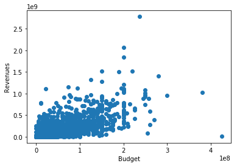

```python
plt.xlabel('Budget')
plt.ylabel('Revenues')
plt.scatter(tmdb_df['budget'],tmdb_df['revenue'])
```

### Research Question 4 (What is the average runtime of the movies?)

```python
avg_runtime = tmdb_df['runtime'].mean()
print("The average runtime of the movies is:{}".format(avg_runtime))
```

```
The average runtime of the movies is:109.22029060716139
```

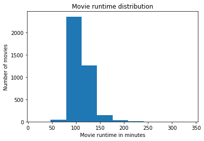

```python
#Plot a histogram of the movie runtimes in the filtered dataset
plt.xlabel('Movie runtime in minutes')
plt.ylabel('Number of movies')
plt.title('Movie runtime distribution')
plt.hist(tmdb_df['runtime'])
```

### Research Question 5 (Is the popularity of a movie related to its runtime?)

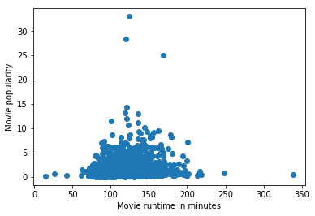

```python
#Plot runtime on the x-axis and popularity on the y-axis
#Can you infer anything from the scatter plot?
plt.xlabel('Movie runtime in minutes')
plt.ylabel('Movie popularity')

plt.scatter(tmdb_df['runtime'],tmdb_df['popularity'])
```

### Research Question 5 (Which year has the maximum number of movies released? Plot a histogram)

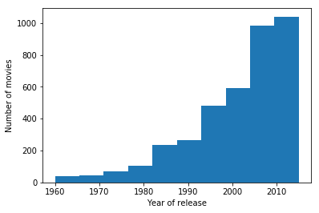

```python
plt.xlabel('Year of release')
plt.ylabel('Number of movies')
plt.hist(tmdb_df['release_year'])
```

## Conclusions

-Revenue collections are not guaranteed to be in line with the budget. A higher budget does not necessarily guarantee a higher revenue collection.

-Most of the movies have a runtime of about 100 minutes.

-It cannot be conclusively stated that the popularity of a movie is related to it's runtime.

**Limitations**: This analysis is an introductory level analysis and is by no means helpful to make business decisions.